# EAES 494 Midterm Starter

RUBRIC

RUBRIC

## Academic Honesty Statement

*I, RUBRIC, hereby state that I will not communicate with or gain information in any way from my classmates, or copy work from past assignments, during this exam, and that all work is my own.*

## Load packages

```r
library(tidyverse)
library(palmerpenguins)
```

## Exericses

### Exericse 1

```r
glimpse(penguins)
```

```
## Rows: 344
## Columns: 8
## $ species           <fct> Adelie, Adelie, Adelie, Adelie, Adelie, Adelie, Adel…
## $ island            <fct> Torgersen, Torgersen, Torgersen, Torgersen, Torgerse…
## $ bill_length_mm    <dbl> 39.1, 39.5, 40.3, NA, 36.7, 39.3, 38.9, 39.2, 34.1, …
## $ bill_depth_mm     <dbl> 18.7, 17.4, 18.0, NA, 19.3, 20.6, 17.8, 19.6, 18.1, …
## $ flipper_length_mm <int> 181, 186, 195, NA, 193, 190, 181, 195, 193, 190, 186…
## $ body_mass_g       <int> 3750, 3800, 3250, NA, 3450, 3650, 3625, 4675, 3475, …
## $ sex               <fct> male, female, female, NA, female, male, female, male…
## $ year              <int> 2007, 2007, 2007, 2007, 2007, 2007, 2007, 2007, 2007…
```

There are 344 rows and 8 variables in the dataset. Three of the variable are categorical, and five are numerical.

### Exericse 2

```r
names(penguins)
```

```
## [1] "species"           "island"            "bill_length_mm"
## [4] "bill_depth_mm"     "flipper_length_mm" "body_mass_g"
## [7] "sex"               "year"
```

All the names are lower case and snake case (no spaces in names).

### Exericse 3

```r
penguins %>%
  count(species)
```

```
## # A tibble: 3 × 2
##   species       n
##   <fct>     <int>
## 1 Adelie      152
## 2 Chinstrap    68
## 3 Gentoo      124
```

We could have used `group_by()` and `summarize()` to sum the number of observations (rows) by `species` group.

### Exericse 4

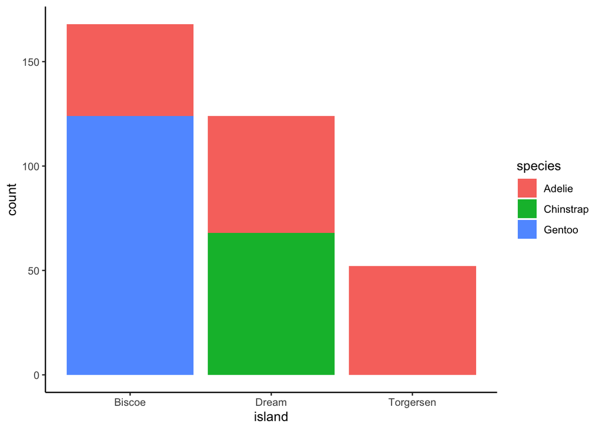

```r
penguins %>%
  ggplot(aes(x = island, fill = species)) +
  geom_bar() +
  theme_classic()
```

### Exericse 5

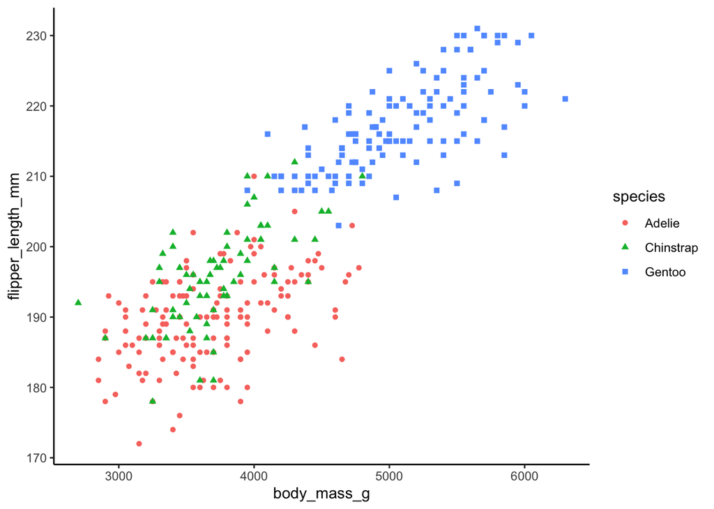

```r
penguins %>%
  ggplot(aes(x = body_mass_g, y = flipper_length_mm, color = species, shape = species)) +
  geom_point() +
  theme_classic()
```

There appears to be a positive association between body mass and flipper length. The Gentoo penguins tend to be larger (higher mass and/or longer flipper length).

### Exericse 6

```r
gentoo_flipper_length <- penguins %>%
  select(flipper_length_mm, sex, island, species) %>%
  filter(species == "Gentoo")
```

### Exericse 7

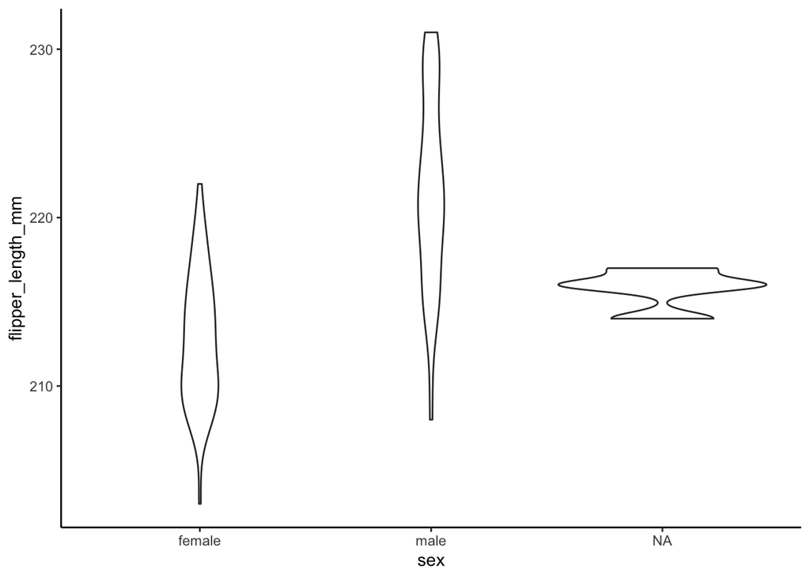

```r
gentoo_flipper_length %>%
  ggplot(aes(x = sex, y = flipper_length_mm)) +
  geom_violin() +
  theme_classic()
```

The `sex` variable is a factor. Factors are composed of a label and a level. The factor levels are assigned to labels by default based on alphabetical order (1 = female, then 2 = male, then 3 = NA).

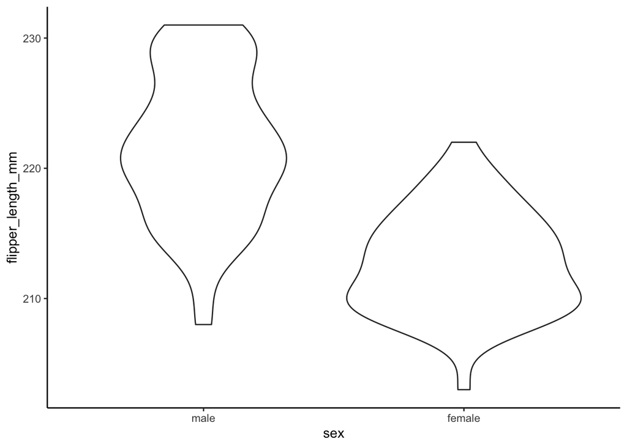

```r
gentoo_flipper_length %>%
  filter(!is.na(sex)) %>%
  mutate(sex = fct_relevel(sex, "male", "female")) %>%
    ggplot(aes(x = sex, y = flipper_length_mm)) +
    geom_violin() +
    theme_classic()
```

### Exericse 8

```r
penguins_with_issues <- read_csv("midterm/data/penguins-issues.csv")
glimpse(penguins_with_issues)
```

```
## Rows: 344
## Columns: 8
## $ species             <chr> "Adelie", "Adelie", "Adelie", "Adelie", "Adelie", …
## $ island              <chr> "Torgersen", "Torgersen", "Torgersen", "Torgersen"…
## $ `bill length mm`    <dbl> 39.1, 39.5, 40.3, NA, 36.7, 39.3, 38.9, 39.2, 34.1…
## $ `bill depth mm`     <dbl> 18.7, 17.4, 18.0, NA, 19.3, 20.6, 17.8, 19.6, 18.1…
## $ `flipper length mm` <dbl> 181, 186, 195, NA, 193, 190, 181, 195, 193, 190, 1…
## $ `body mass g`       <dbl> 3750, 3800, 3250, NA, 3450, 3650, 3625, 4675, 3475…
## $ sex                 <chr> "male", "#", "female", NA, "female", "male", "fema…
## $ year                <chr> "2007", ".", "2007", "2007", "2007", "2007", "2007…
```

The variable names have spaces, and the sex has a bad value “#” and year has a bad entry “.” causing them to be coerced to character type data.

```r
penguins_with_issues <- read_csv("midterm/data/penguins-issues.csv", na = c(".", "#"), name_repair = "universal")
```

```
## * `bill length mm` -> bill.length.mm
## * `bill depth mm` -> bill.depth.mm
## * `flipper length mm` -> flipper.length.mm
## * `body mass g` -> body.mass.g
```

```r
glimpse(penguins_with_issues)
```

```
## Rows: 344
## Columns: 8
## $ species           <chr> "Adelie", "Adelie", "Adelie", "Adelie", "Adelie", "A…
## $ island            <chr> "Torgersen", "Torgersen", "Torgersen", "Torgersen", …
## $ bill.length.mm    <chr> "39.1", "39.5", "40.3", "NA", "36.7", "39.3", "38.9"…
## $ bill.depth.mm     <chr> "18.7", "17.4", "18", "NA", "19.3", "20.6", "17.8", …
## $ flipper.length.mm <chr> "181", "186", "195", "NA", "193", "190", "181", "195…
## $ body.mass.g       <chr> "3750", "3800", "3250", "NA", "3450", "3650", "3625"…
## $ sex               <chr> "male", NA, "female", "NA", "female", "male", "femal…
## $ year              <dbl> 2007, NA, 2007, 2007, 2007, 2007, 2007, 2007, 2007, …
```